# Predicting Excessive Enforcement Patterns in Police Behavior After Vehicles Stops in New York

## Evaluation on the Test Set

```r
knn_fit <- kknn::kknn(
  f_knn,
  train     = df_knn_tr,
  test      = df_knn_te,
  k         = best_k,
  kernel    = "optimal",
  na.action = na.pass
)

# Positive class column: kknn coerces response to factor; locate "1" level
pos_col  <- which(colnames(knn_fit$prob) == "1")
if (length(pos_col) == 0) pos_col <- ncol(knn_fit$prob)
prob_knn  <- as.numeric(knn_fit$prob[, pos_col])
roc_knn   <- pROC::roc(test$arrested, prob_knn, quiet = TRUE)
auc_knn   <- as.numeric(pROC::auc(roc_knn))
thr_knn   <- best_thresh(roc_knn)
class_knn <- as.integer(prob_knn >= thr_knn)
met_knn   <- class_metrics(test$arrested, class_knn)

cat(sprintf(
  "AUC: %.4f  |  Threshold (Youden): %.4f\nSensitivity: %.3f  |  Specificity: %.3f  |  Balanced accuracy: %.3f\n",
  auc_knn, thr_knn, met_knn$sensitivity, met_knn$specificity, met_knn$balanced_acc
))
```

```
## AUC: 0.6536  |  Threshold (Youden): 0.5184
## Sensitivity: 0.669  |  Specificity: 0.560  |  Balanced accuracy: 0.615
```

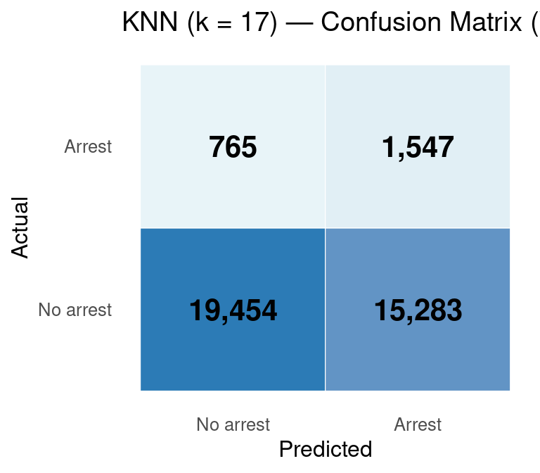

```r
plot_cm(test$arrested, class_knn,
        title = sprintf("KNN (k = %d) — Confusion Matrix (Youden threshold)", best_k))
```

```r
compute_metrics(test$arrested, prob_knn, sprintf("KNN (k = %d)", best_k)) %>%
  kbl(
    caption   = sprintf("KNN (k = %d) — full evaluation metrics (test set, Youden threshold)", best_k),
    col.names = c("Model","AUC","PR-AUC","Log-Loss","Brier",
                  "Threshold","Sensitivity","Specificity","Precision","F1","MCC","Bal. Acc.")
  ) %>%
  kable_styling(bootstrap_options = c("striped","condensed"), full_width = TRUE)
```

KNN (k = 17) — full evaluation metrics (test set, Youden threshold)

| Model | AUC | PR-AUC | Log-Loss | Brier | Threshold | Sensitivity | Specificity | Precision | F1 | MCC | Bal. Acc. |
| --- | --- | --- | --- | --- | --- | --- | --- | --- | --- | --- | --- |
| KNN (k = 17) | 0.6536 | 0.0991 | 0.7833 | 0.2706 | 0.5184 | 0.669 | 0.56 | 0.092 | 0.162 | 0.111 | 0.615 |

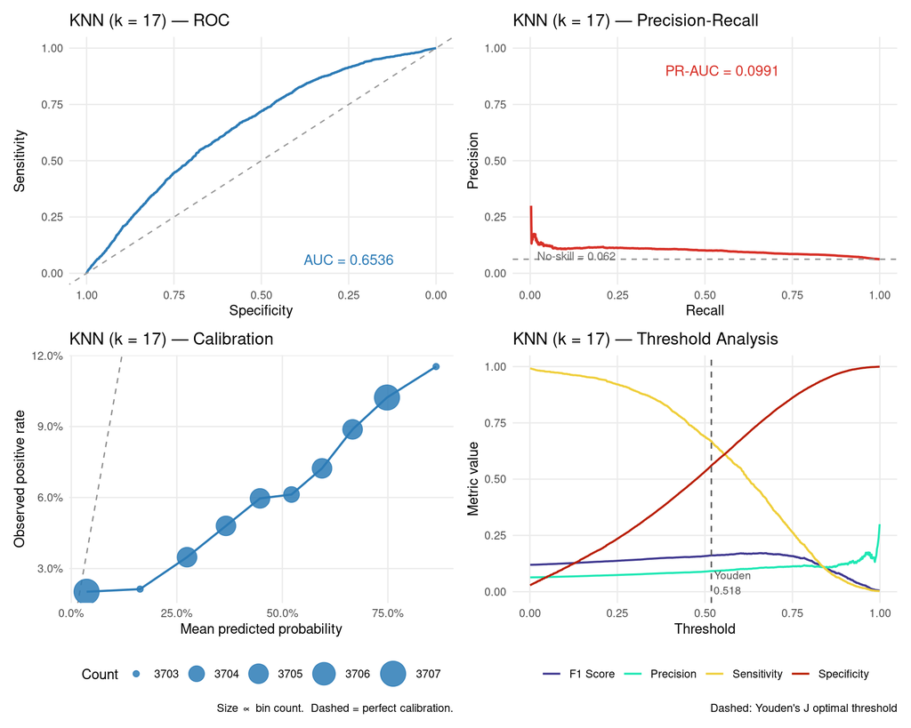

```r
eval_quad_plot(test$arrested, prob_knn, sprintf("KNN (k = %d)", best_k))
```

# ix · GAM

## Setup

A Generalized Additive Model (GAM) extends logistic regression by allowing selected continuous predictors to enter through smooth functions rather than linear terms. We fit with `mgcv::gam` using `family = binomial` and REML smoothness selection. Two continuous predictors receive data-driven smooth terms:

All other predictors (`year`, `month`, `weekday`, `sex`, `ethnicity`, geographic grouping) remain parametric factors, matching the selected predictor forms from section ii.

```r
# hour is stored as factor after factor-prep; recover numeric version for s()
train_gam <- train %>% mutate(hour_num = as.integer(as.character(hour)))
test_gam  <- test  %>% mutate(hour_num = as.integer(as.character(hour)))
```

## Model Fit

```r
f_gam <- as.formula(sprintf(
  "arrested ~ year + month + weekday + s(hour_num, bs = 'cc', k = 10) + %s + sex + ethnicity + s(age, bs = 'cr', k = 6)",
  use_geo
))

mod_gam <- mgcv::gam(f_gam, family = binomial, data = train_gam, method = "REML")
summary(mod_gam)
```

```
##
## Family: binomial
## Link function: logit
##
## Formula:
## arrested ~ year + month + weekday + s(hour_num, bs = "cc", k = 10) +
##     boro + sex + ethnicity + s(age, bs = "cr", k = 6)
##
## Parametric coefficients:
##                                   Estimate Std. Error z value Pr(>|z|)
## (Intercept)                       -2.96206    0.09186 -32.246  < 2e-16 ***
## year2024                           0.13463    0.03796   3.547 0.000390 ***
## year2025                           0.20897    0.03698   5.651 1.59e-08 ***
## month2                             0.03010    0.07444   0.404 0.685988
## month3                             0.10014    0.06959   1.439 0.150144
## month4                             0.14569    0.06657   2.189 0.028622 *
## month5                             0.14256    0.06558   2.174 0.029726 *
## month6                             0.13686    0.06402   2.138 0.032528 *
## month7                             0.20988    0.06284   3.340 0.000839 ***
## month8                             0.04792    0.06421   0.746 0.455479
## month9                             0.23093    0.06320   3.654 0.000258 ***
## month10                            0.14586    0.06340   2.301 0.021405 *
## month11                            0.07807    0.06642   1.175 0.239823
## month12                           -0.10869    0.07494  -1.450 0.146949
## weekdayTuesday                     0.12349    0.04968   2.486 0.012930 *
## weekdayWednesday                   0.03377    0.04881   0.692 0.489051
## weekdayThursday                   -0.01333    0.04912  -0.271 0.786068
## weekdayFriday                     -0.12903    0.05047  -2.557 0.010566 *
## weekdaySaturday                   -0.08870    0.05108  -1.737 0.082453 .
## weekdaySunday                     -0.13239    0.05218  -2.537 0.011182 *
## boroBrooklyn (North)              -0.87775    0.03968 -22.120  < 2e-16 ***
## boroBrooklyn (South)              -0.53912    0.03817 -14.126  < 2e-16 ***
## boroManhattan (North)             -1.12023    0.04476 -25.029  < 2e-16 ***
## boroManhattan (South)             -1.07262    0.05316 -20.176  < 2e-16 ***
## boroQueens (North)                -0.97966    0.03902 -25.104  < 2e-16 ***
## boroQueens (South)                -0.70645    0.04890 -14.447  < 2e-16 ***
## boroStaten Island                 -0.47393    0.13895  -3.411 0.000648 ***
## sexF                              -1.17405    0.12378  -9.485  < 2e-16 ***
## sexU                               0.08068    0.34612   0.233 0.815689
## ethnicityAsian / Pacific Islander -0.67450    0.08183  -8.243  < 2e-16 ***
## ethnicityBlack                     0.44667    0.05999   7.446 9.60e-14 ***
## ethnicityHispanic                  0.64177    0.05742  11.176  < 2e-16 ***
## ethnicityOther                    -2.56949    0.41266  -6.227 4.77e-10 ***
## ethnicityUnknown                  -1.05520    0.09930 -10.627  < 2e-16 ***
## ---
## Signif. codes:  0 '***' 0.001 '**' 0.01 '*' 0.05 '.' 0.1 ' ' 1
##
## Approximate significance of smooth terms:
##              edf Ref.df Chi.sq p-value
## s(hour_num) 7.52  8.000   1164  <2e-16 ***
## s(age)      4.66  4.918    108  <2e-16 ***
## ---
## Signif. codes:  0 '***' 0.001 '**' 0.01 '*' 0.05 '.' 0.1 ' ' 1
##
## R-sq.(adj) =  0.0391   Deviance explained = 9.61%
## -REML =  27023  Scale est. = 1         n = 143566
```

## Smooth Term Plots

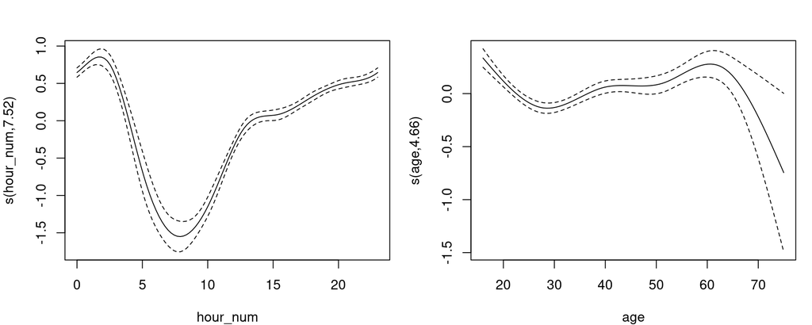

```r
par(mfrow = c(1, 2), mar = c(4, 4, 2.5, 1))
plot(mod_gam, shade = TRUE, shade.col = "lightblue", seWithMean = TRUE,
     pages = 0, scale = 0)
```

```r
par(mfrow = c(1, 1))
```

## Evaluation on the Test Set

```r
prob_gam  <- predict(mod_gam, newdata = test_gam, type = "response")
roc_gam   <- pROC::roc(test$arrested, prob_gam, quiet = TRUE)
auc_gam   <- as.numeric(pROC::auc(roc_gam))
thr_gam   <- best_thresh(roc_gam)
class_gam <- as.integer(prob_gam >= thr_gam)
met_gam   <- class_metrics(test$arrested, class_gam)

cat(sprintf(
  "AUC: %.4f  |  Threshold (Youden): %.4f\nSensitivity: %.3f  |  Specificity: %.3f  |  Balanced accuracy: %.3f\n",
  auc_gam, thr_gam, met_gam$sensitivity, met_gam$specificity, met_gam$balanced_acc
))
```

```
## AUC: 0.6897  |  Threshold (Youden): 0.0554
## Sensitivity: 0.647  |  Specificity: 0.634  |  Balanced accuracy: 0.640
```

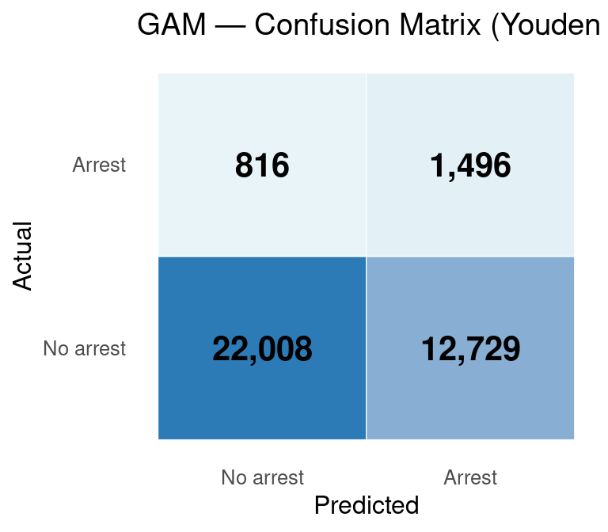

```r
plot_cm(test$arrested, class_gam, title = "GAM — Confusion Matrix (Youden threshold)")
```

```r
compute_metrics(test$arrested, prob_gam, "GAM") %>%
  kbl(
    caption   = "GAM — full evaluation metrics (test set, Youden threshold)",
    col.names = c("Model","AUC","PR-AUC","Log-Loss","Brier",
                  "Threshold","Sensitivity","Specificity","Precision","F1","MCC","Bal. Acc.")
  ) %>%
  kable_styling(bootstrap_options = c("striped","condensed"), full_width = TRUE)
```

GAM — full evaluation metrics (test set, Youden threshold)

| Model | AUC | PR-AUC | Log-Loss | Brier | Threshold | Sensitivity | Specificity | Precision | F1 | MCC | Bal. Acc. |
| --- | --- | --- | --- | --- | --- | --- | --- | --- | --- | --- | --- |
| GAM | 0.6897 | 0.1247 | 0.2235 | 0.057 | 0.0554 | 0.647 | 0.634 | 0.105 | 0.181 | 0.14 | 0.64 |

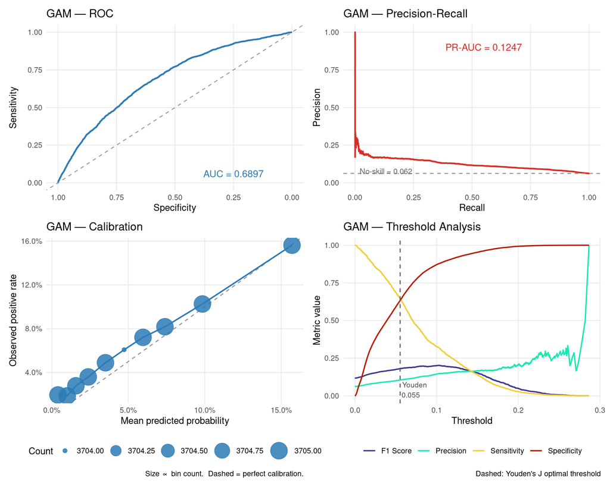

```r
eval_quad_plot(test$arrested, prob_gam, "GAM")
```

# x · All-Method Comparison

## ROC Curves

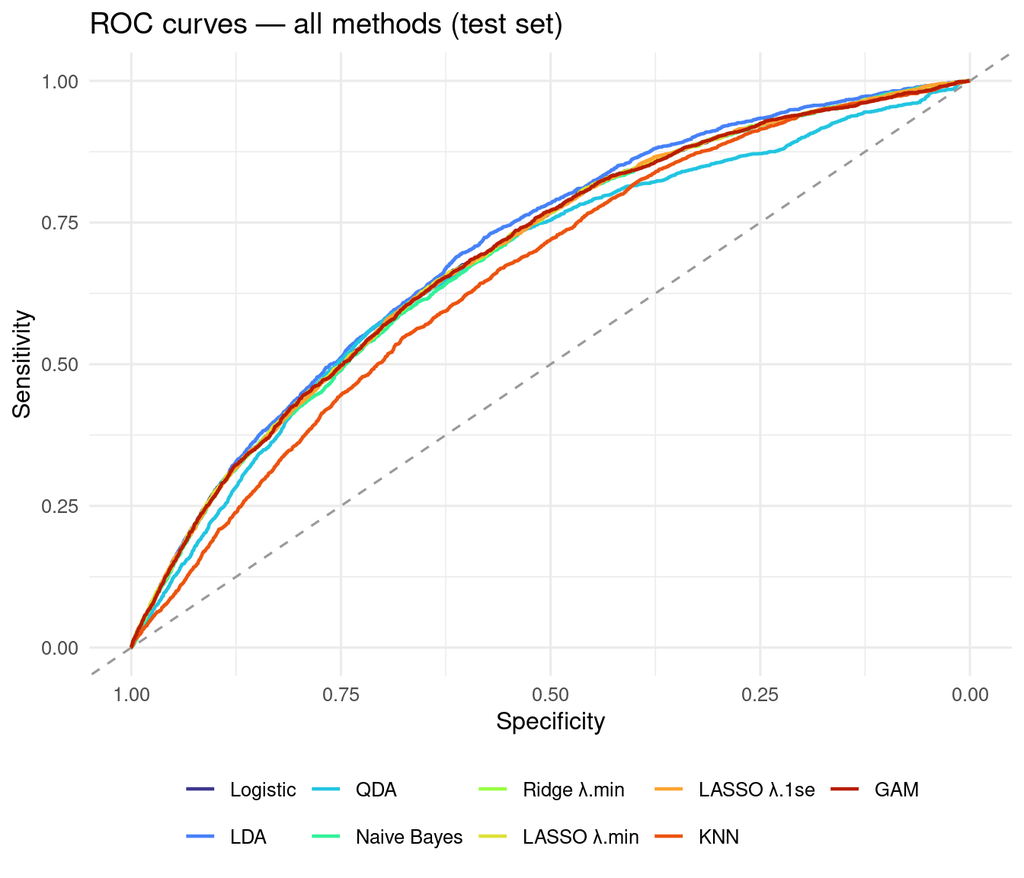

```r
# prob_logit / roc_logit / auc_logit already defined in section ii-b
roc_list <- list(
  "Logistic"     = roc_logit,
  "LDA"          = roc_lda,
  "QDA"          = roc_qda,
  "Naive Bayes"  = roc_nb,
  "Ridge λ.min"  = roc_ridge,
  "LASSO λ.min"  = roc_lasso_min,
  "LASSO λ.1se"  = roc_lasso_1se,
  "KNN"          = roc_knn,
  "GAM"          = roc_gam
)

pROC::ggroc(roc_list, linewidth = 0.8) +
  geom_abline(slope = 1, intercept = 1, linetype = "dashed", colour = "grey60") +
  scale_colour_viridis_d(option = "turbo", begin = 0.05, end = 0.92) +
  labs(
    x      = "Specificity",
    y      = "Sensitivity",
    colour = NULL,
    title  = "ROC curves — all methods (test set)"
  ) +
  theme_minimal(base_size = 12) +
  theme(legend.position = "bottom")
```

## Metrics Summary

```r
# All threshold/class/metric objects already defined in per-model sections
bind_rows(
  compute_metrics(test$arrested, prob_logit,     "Logistic"),
  compute_metrics(test$arrested, prob_lda,       "LDA"),
  compute_metrics(test$arrested, prob_qda,       "QDA"),
  compute_metrics(test$arrested, prob_nb,        "Naive Bayes"),
  compute_metrics(y_test,        prob_ridge,     "Ridge (λ.min)"),
  compute_metrics(y_test,        prob_lasso_min, "LASSO λ.min"),
  compute_metrics(y_test,        prob_lasso_1se, "LASSO λ.1se"),
  compute_metrics(test$arrested, prob_knn,       sprintf("KNN (k = %d)", best_k)),
  compute_metrics(test$arrested, prob_gam,       "GAM")
) %>%
  kbl(
    caption   = "All methods — full evaluation metrics (test set, Youden threshold)",
    col.names = c("Method","AUC","PR-AUC","Log-Loss","Brier",
                  "Threshold","Sensitivity","Specificity","Precision","F1","MCC","Bal. Acc.")
  ) %>%
  kable_styling(bootstrap_options = c("striped","hover","condensed"), full_width = TRUE) %>%
  row_spec(
    which.max(c(as.numeric(pROC::auc(roc_logit)), auc_lda, auc_qda, auc_nb, auc_ridge, auc_lasso_min, auc_lasso_1se, auc_knn, auc_gam)),
    bold = TRUE, color = "white", background = "#2c7bb6"
    )
```

All methods — full evaluation metrics (test set, Youden threshold)

| Method | AUC | PR-AUC | Log-Loss | Brier | Threshold | Sensitivity | Specificity | Precision | F1 | MCC | Bal. Acc. |
| --- | --- | --- | --- | --- | --- | --- | --- | --- | --- | --- | --- |
| Logistic | 0.6903 | 0.1249 | 0.2235 | 0.0569 | 0.0579 | 0.631 | 0.652 | 0.108 | 0.184 | 0.142 | 0.642 |
| LDA | 0.7011 | 0.1263 | 0.2209 | 0.0570 | 0.0415 | 0.724 | 0.579 | 0.103 | 0.180 | 0.148 | 0.651 |
| QDA | 0.6698 | 0.1099 | 4.2487 | 0.4807 | 0.9966 | 0.609 | 0.671 | 0.110 | 0.186 | 0.142 | 0.640 |
| Naive Bayes | 0.6868 | 0.1196 | 0.2270 | 0.0576 | 0.0401 | 0.735 | 0.538 | 0.096 | 0.169 | 0.132 | 0.636 |
| Ridge (λ.min) | 0.6900 | 0.1246 | 0.2223 | 0.0569 | 0.0573 | 0.644 | 0.638 | 0.106 | 0.182 | 0.141 | 0.641 |
| LASSO λ.min | 0.6902 | 0.1250 | 0.2232 | 0.0569 | 0.0547 | 0.662 | 0.622 | 0.104 | 0.180 | 0.140 | 0.642 |
| LASSO λ.1se | 0.6896 | 0.1232 | 0.2217 | 0.0569 | 0.0573 | 0.654 | 0.627 | 0.104 | 0.180 | 0.139 | 0.640 |
| KNN (k = 17) | 0.6536 | 0.0991 | 0.7833 | 0.2706 | 0.5184 | 0.669 | 0.560 | 0.092 | 0.162 | 0.111 | 0.615 |
| GAM | 0.6897 | 0.1247 | 0.2235 | 0.0570 | 0.0554 | 0.647 | 0.634 | 0.105 | 0.181 | 0.140 | 0.640 |

# xi · Model Diagnostics

## Logistic Regression — Multicollinearity (VIF)

Variance Inflation Factors measure how much each predictor’s variance is inflated by collinearity with the others. A VIF > 5 indicates moderate concern; VIF > 10 warrants action (dropping or combining predictors). Because `mod_logit_best` contains multi-level factors, `car::vif()` returns the generalised VIF (GVIF) scaled by degrees of freedom: $\text{GVIF}^{1/(2\,\text{df})}$ is comparable to the square root of a standard VIF.

```r
vif_tbl <- as.data.frame(car::vif(mod_logit_best))
vif_tbl$predictor <- rownames(vif_tbl)
rownames(vif_tbl) <- NULL

# Rename columns robustly (vif() returns 3-col df for factors)
if (ncol(vif_tbl) == 4) {
  names(vif_tbl)[1:3] <- c("GVIF", "Df", "GVIF_adj")
} else {
  names(vif_tbl)[1] <- "GVIF"
  vif_tbl$Df       <- 1
  vif_tbl$GVIF_adj <- sqrt(vif_tbl$GVIF)
}

vif_tbl %>%
  arrange(desc(GVIF_adj)) %>%
  mutate(flag = ifelse(GVIF_adj > sqrt(5), "⚠ >5", "OK")) %>%
  kbl(
    digits  = 3,
    caption = "Logistic regression — Generalised VIF (GVIF^(1/2df) comparable to sqrt(VIF))"
  ) %>%
  kable_styling(bootstrap_options = c("striped", "condensed"), full_width = FALSE)
```

Logistic regression — Generalised VIF (GVIF^(1/2df) comparable to sqrt(VIF))

| GVIF | Df | GVIF_adj | predictor | flag |
| --- | --- | --- | --- | --- |
| 1.253 | 5 | 1.023 | ethnicity | OK |
| 1.212 | 7 | 1.014 | boro | OK |
| 1.054 | 2 | 1.013 | year | OK |
| 1.049 | 2 | 1.012 | sex | OK |
| 1.049 | 6 | 1.004 | age_bracket | OK |
| 1.048 | 6 | 1.004 | weekday | OK |
| 1.059 | 11 | 1.003 | month | OK |
| 1.099 | 23 | 1.002 | hour | OK |

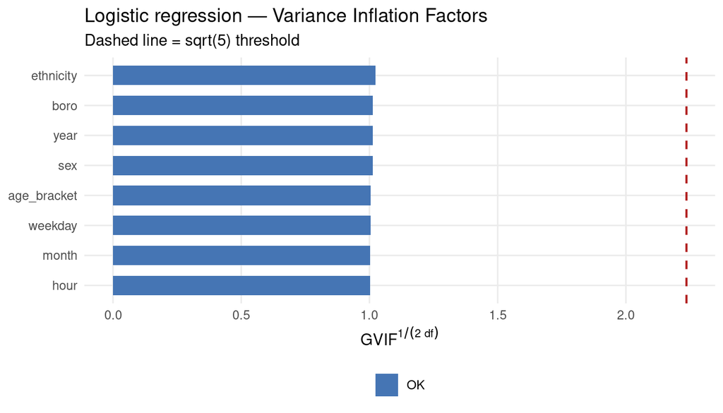

```r
ggplot(vif_tbl, aes(x = reorder(predictor, GVIF_adj), y = GVIF_adj,
                    fill = GVIF_adj > sqrt(5))) +
  geom_col(width = 0.65) +
  geom_hline(yintercept = sqrt(5), linetype = "dashed", colour = "firebrick", linewidth = 0.7) +
  scale_fill_manual(values = c("FALSE" = "#4575b4", "TRUE" = "#d73027"),
                    labels = c("OK", ">5 threshold"), name = NULL) +
  coord_flip() +
  labs(
    x     = NULL,
    y     = expression(GVIF^{1/(2~df)}),
    title = "Logistic regression — Variance Inflation Factors",
    subtitle = "Dashed line = sqrt(5) threshold"
  ) +
  theme_minimal(base_size = 11) +
  theme(legend.position = "bottom", panel.grid.minor = element_blank())
```

Predictors with $\text{GVIF}^{1/(2\,\text{df})} > \sqrt{5}$ (red bars, if any) share substantial variance with other covariates. For this model the main risk is between `month` and `year` (temporal confounding) and among demographic variables if certain combinations are sparse. Mild inflation is acceptable given the large sample size; severe inflation would destabilise coefficient estimates and widen confidence intervals without affecting predictive accuracy.

## Logistic Regression — Influential Observations (Cook’s Distance)

Cook’s Distance measures how much all fitted values change when observation $i$ is deleted. Values above $4/n$ (a common rule of thumb) flag leverage points that may disproportionately drive the estimates.

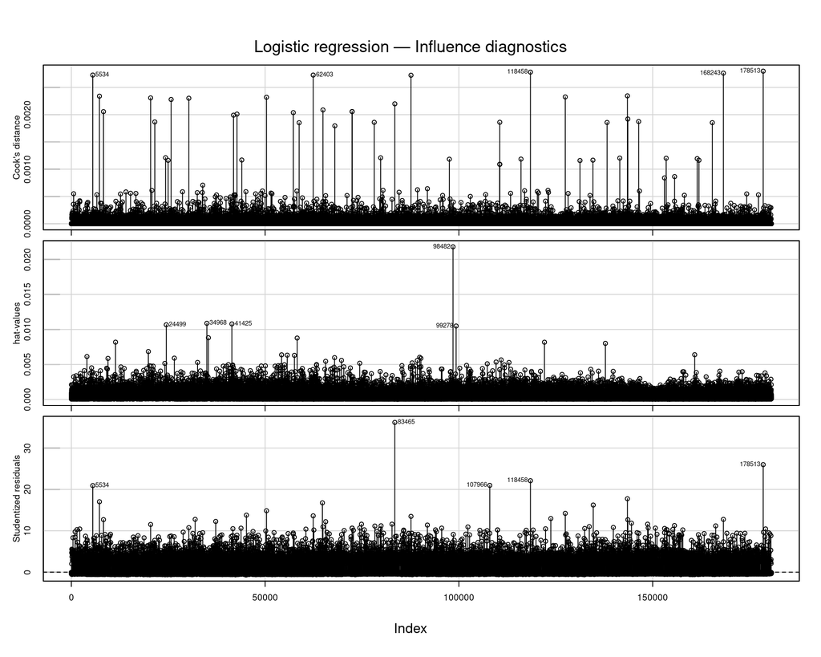

```r
car::influenceIndexPlot(
  mod_logit_best,
  vars  = c("Cook", "hat", "Studentized"),
  id    = list(n = 5, cex = 0.7),
  main  = "Logistic regression — Influence diagnostics"
)
```

## Naive Bayes — Predictor Correlation (Independence Assumption Check)

Naive Bayes assumes conditional independence of all features given the class. This is almost certainly violated: time-of-day, borough, and demographic covariates are jointly distributed. The heatmap below shows the Pearson/phi correlation matrix of the dummy-encoded predictor matrix on the training set. Strong off-diagonal correlations directly quantify how badly the independence assumption is violated.

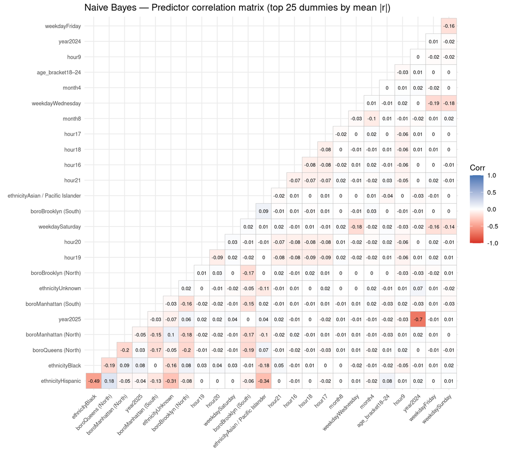

```r
# Build dummy matrix from training data using the same formula (drop intercept)
X_nb_corr <- model.matrix(f_final, data = train)[, -1]

# Correlation matrix (Pearson on 0/1 dummies = phi coefficient)
cor_mat <- cor(X_nb_corr)

# Keep only the top 25 columns/rows by mean absolute off-diagonal correlation
# to keep the plot legible when f_final expands to many dummies
mean_abs_cor <- colMeans(abs(cor_mat) - diag(ncol(cor_mat)) / ncol(cor_mat))
top_idx      <- order(mean_abs_cor, decreasing = TRUE)[seq_len(min(25, ncol(cor_mat)))]
cor_sub      <- cor_mat[top_idx, top_idx]

ggcorrplot(
  cor_sub,
  method   = "square",
  type     = "lower",
  lab      = TRUE,
  lab_size = 2.2,
  colors   = c("#d73027", "white", "#4575b4"),
  title    = "Naive Bayes — Predictor correlation matrix (top 25 dummies by mean |r|)",
  ggtheme  = theme_minimal(base_size = 10)
) +
  theme(
    axis.text.x     = element_text(angle = 45, hjust = 1, size = 7),
    axis.text.y     = element_text(size = 7),
    legend.position = "right"
  )
```

Pairs with $|r| > 0.3$ signal meaningful shared information. The independence assumption is most strained when dummy variables from the *same* factor (e.g., multiple `boro` levels) are correlated with those from another factor (e.g., `ethnicity` or `time_bracket`), because Naive Bayes then effectively double-counts that shared signal when computing posterior probabilities. Despite this, Naive Bayes often generalises well in practice—its posterior *rankings* (used for AUC) are more robust to the violation than its posterior *magnitudes* (used for calibration), which is why Log-Loss and Brier score tend to suffer more than AUC for this model class.

## LDA — Discriminant Score Separation (LD1)

Linear Discriminant Analysis projects each observation onto one or more linear discriminant axes that maximise between-class variance relative to within-class variance. For a two-class problem there is a single axis, **LD1**. Good separation requires the two class distributions on LD1 to be well apart relative to their spread; heavy overlap signals that the linear boundary will struggle to separate `arrested = 1` from `arrested = 0`.

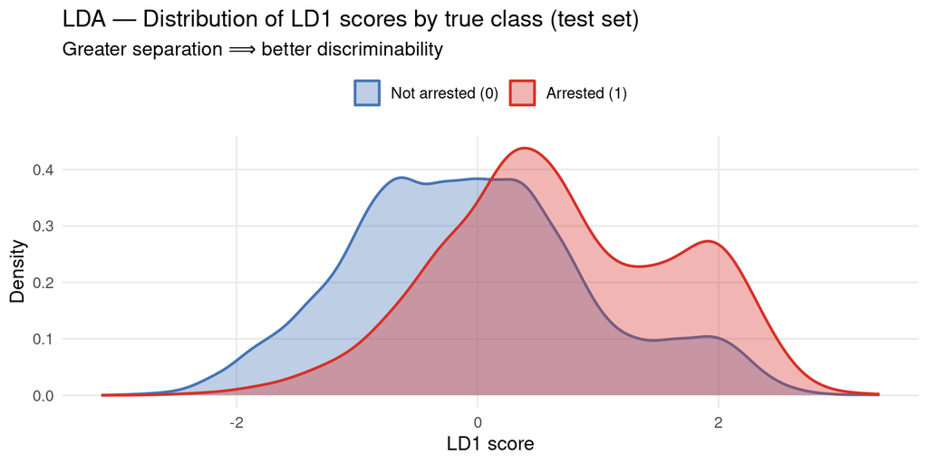

```r
lda_scores <- data.frame(
  LD1      = predict(mod_lda, newdata = test)$x[, 1],
  arrested = factor(test$arrested, levels = c(0, 1),
                    labels = c("Not arrested (0)", "Arrested (1)"))
)

ggplot(lda_scores, aes(x = LD1, fill = arrested, colour = arrested)) +
  geom_density(alpha = 0.35, linewidth = 0.8) +
  scale_fill_manual(values   = c("Not arrested (0)" = "#4575b4",
                                  "Arrested (1)"     = "#d73027")) +
  scale_colour_manual(values = c("Not arrested (0)" = "#4575b4",
                                  "Arrested (1)"     = "#d73027")) +
  labs(
    x        = "LD1 score",
    y        = "Density",
    fill     = NULL, colour = NULL,
    title    = "LDA — Distribution of LD1 scores by true class (test set)",
    subtitle = "Greater separation ⟹ better discriminability"
  ) +
  theme_minimal(base_size = 12) +
  theme(legend.position = "top", panel.grid.minor = element_blank())
```

Well-separated modes indicate that LD1 alone carries strong discriminative signal. Significant overlap—common when the positive class is rare and the feature space is high-dimensional—explains why AUC is imperfect even when the linear boundary is optimal under Gaussian assumptions.

## QDA — Posterior Probability Separation

QDA does not produce a single linear score; it estimates class-conditional Gaussians with separate covariance matrices per class and returns posterior probabilities directly. Plotting the distribution of $\hat{P}(\text{arrested} = 1 \mid \mathbf{x})$ by true class reveals whether QDA assigns high confidence to the correct class: a well-calibrated and discriminating model concentrates the positive class near 1 and the negative class near 0.

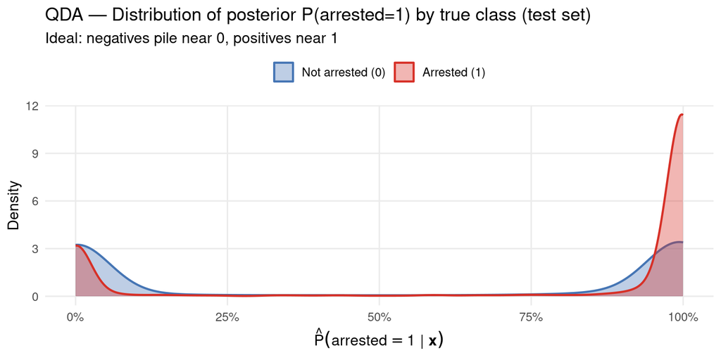

```r
qda_post <- data.frame(
  prob_arrested = predict(mod_qda, newdata = test)$posterior[, "1"],
  arrested      = factor(test$arrested, levels = c(0, 1),
                         labels = c("Not arrested (0)", "Arrested (1)"))
)

ggplot(qda_post, aes(x = prob_arrested, fill = arrested, colour = arrested)) +
  geom_density(alpha = 0.35, linewidth = 0.8) +
  scale_fill_manual(values   = c("Not arrested (0)" = "#4575b4",
                                  "Arrested (1)"     = "#d73027")) +
  scale_colour_manual(values = c("Not arrested (0)" = "#4575b4",
                                  "Arrested (1)"     = "#d73027")) +
  scale_x_continuous(limits = c(0, 1), labels = scales::percent_format()) +
  labs(
    x        = expression(hat(P)(arrested == 1 ~ "|" ~ bold(x))),
    y        = "Density",
    fill     = NULL, colour = NULL,
    title    = "QDA — Distribution of posterior P(arrested=1) by true class (test set)",
    subtitle = "Ideal: negatives pile near 0, positives near 1"
  ) +
  theme_minimal(base_size = 12) +
  theme(legend.position = "top", panel.grid.minor = element_blank())
```

If the two density curves overlap substantially in the middle of the probability axis, QDA is uncertain for many observations—reflecting either genuine noise in the features or a violation of its Gaussian equal-covariance assumption (note: unlike LDA, QDA allows unequal covariances, which gives it more flexibility but also more variance in small samples or with sparse classes).

## Ridge — Coefficient Paths and CV Deviance vs $\lambda$

The coefficient path shows how each predictor’s coefficient shrinks as the $\ell_2$ penalty $\lambda$ increases. Unlike LASSO, Ridge never zeroes out coefficients — all shrink smoothly toward zero. The CV deviance curve (right panel) identifies $\lambda_{\min}$ (lowest CV loss) and $\lambda_{\text{1se}}$ (most regularised model within one standard error).

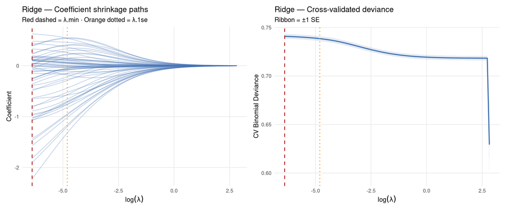

```r
# Coefficient path
ridge_fit   <- cv_ridge$glmnet.fit
coef_mat_r  <- as.matrix(coef(ridge_fit))[-1, ]   # drop intercept row
log_lam_r   <- log(ridge_fit$lambda)

coef_path_r <- as.data.frame(t(coef_mat_r)) %>%
  mutate(log_lambda = log_lam_r) %>%
  tidyr::pivot_longer(-log_lambda, names_to = "predictor", values_to = "coef")

p_ridge_path <- ggplot(coef_path_r,
                        aes(x = log_lambda, y = coef, group = predictor)) +
  geom_line(alpha = 0.35, linewidth = 0.5, colour = "#4575b4") +
  geom_vline(xintercept = log(cv_ridge$lambda.min), linetype = "dashed",
             colour = "firebrick", linewidth = 0.7) +
  geom_vline(xintercept = log(cv_ridge$lambda.1se), linetype = "dotted",
             colour = "darkorange", linewidth = 0.7) +
  labs(x = expression(log(lambda)), y = "Coefficient",
       title = "Ridge — Coefficient shrinkage paths",
       subtitle = "Red dashed = λ.min · Orange dotted = λ.1se") +
  theme_minimal(base_size = 11) +
  theme(panel.grid.minor = element_blank())

# CV deviance curve
cv_df_r <- data.frame(
  log_lambda = log(cv_ridge$lambda),
  cvm        = cv_ridge$cvm,
  cvup       = cv_ridge$cvup,
  cvlo       = cv_ridge$cvlo
)

p_ridge_cv <- ggplot(cv_df_r, aes(x = log_lambda, y = cvm)) +
  geom_ribbon(aes(ymin = cvlo, ymax = cvup), alpha = 0.15, fill = "#4575b4") +
  geom_line(colour = "#4575b4", linewidth = 0.9) +
  geom_vline(xintercept = log(cv_ridge$lambda.min), linetype = "dashed",
             colour = "firebrick", linewidth = 0.7) +
  geom_vline(xintercept = log(cv_ridge$lambda.1se), linetype = "dotted",
             colour = "darkorange", linewidth = 0.7) +
  labs(x = expression(log(lambda)), y = "CV Binomial Deviance",
       title = "Ridge — Cross-validated deviance",
       subtitle = "Ribbon = ±1 SE") +
  theme_minimal(base_size = 11) +
  theme(panel.grid.minor = element_blank())

p_ridge_path + p_ridge_cv
```

Ridge paths confirm that no predictor dominates: all coefficients shrink proportionally, and the flat plateau at large $\lambda$ is expected — Ridge always retains the full predictor set. The CV curve’s minimum locates the optimal bias–variance trade-off; if $\lambda_{\min}$ and $\lambda_{\text{1se}}$ are far apart, the model is sensitive to regularisation strength.

## LASSO — Coefficient Paths and CV Deviance vs $\lambda$

LASSO’s $\ell_1$ penalty induces sparsity: as $\lambda$ grows, predictors are progressively zeroed out. The coefficient path reveals which predictors survive at $\lambda_{\min}$ and which are eliminated at the more parsimonious $\lambda_{\text{1se}}$.

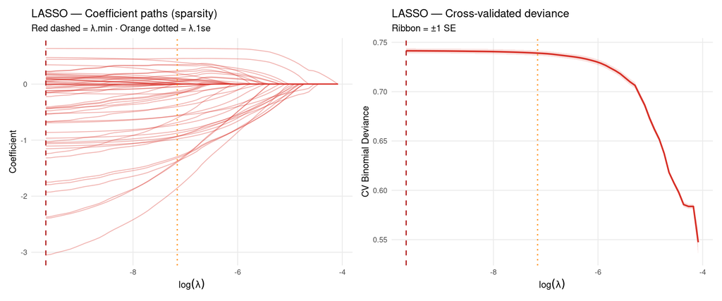

```r
lasso_fit   <- cv_lasso$glmnet.fit
coef_mat_l  <- as.matrix(coef(lasso_fit))[-1, ]
log_lam_l   <- log(lasso_fit$lambda)

coef_path_l <- as.data.frame(t(coef_mat_l)) %>%
  mutate(log_lambda = log_lam_l) %>%
  tidyr::pivot_longer(-log_lambda, names_to = "predictor", values_to = "coef")

p_lasso_path <- ggplot(coef_path_l,
                        aes(x = log_lambda, y = coef, group = predictor)) +
  geom_line(alpha = 0.35, linewidth = 0.5, colour = "#d73027") +
  geom_vline(xintercept = log(cv_lasso$lambda.min), linetype = "dashed",
             colour = "firebrick", linewidth = 0.7) +
  geom_vline(xintercept = log(cv_lasso$lambda.1se), linetype = "dotted",
             colour = "darkorange", linewidth = 0.7) +
  labs(x = expression(log(lambda)), y = "Coefficient",
       title = "LASSO — Coefficient paths (sparsity)",
       subtitle = "Red dashed = λ.min · Orange dotted = λ.1se") +
  theme_minimal(base_size = 11) +
  theme(panel.grid.minor = element_blank())

cv_df_l <- data.frame(
  log_lambda = log(cv_lasso$lambda),
  cvm        = cv_lasso$cvm,
  cvup       = cv_lasso$cvup,
  cvlo       = cv_lasso$cvlo
)

p_lasso_cv <- ggplot(cv_df_l, aes(x = log_lambda, y = cvm)) +
  geom_ribbon(aes(ymin = cvlo, ymax = cvup), alpha = 0.15, fill = "#d73027") +
  geom_line(colour = "#d73027", linewidth = 0.9) +
  geom_vline(xintercept = log(cv_lasso$lambda.min), linetype = "dashed",
             colour = "firebrick", linewidth = 0.7) +
  geom_vline(xintercept = log(cv_lasso$lambda.1se), linetype = "dotted",
             colour = "darkorange", linewidth = 0.7) +
  labs(x = expression(log(lambda)), y = "CV Binomial Deviance",
       title = "LASSO — Cross-validated deviance",
       subtitle = "Ribbon = ±1 SE") +
  theme_minimal(base_size = 11) +
  theme(panel.grid.minor = element_blank())

p_lasso_path + p_lasso_cv
```

The point where paths first leave zero marks each predictor’s entry into the model. Predictors that survive to $\lambda_{\text{1se}}$ are the most robustly informative signal carriers. A wide flat region in the CV curve indicates that the model is relatively insensitive to $\lambda$ in that range — the bias–variance trade-off is shallow — while a sharp minimum suggests strong sensitivity.

## GAM — Smoothness Diagnostics (`gam.check`)

`mgcv::gam.check()` produces four residual plots (Q-Q, residuals vs fitted, histogram of residuals, response vs fitted values) and tests whether the basis dimension $k$ is sufficient for each smooth term. A significant $p$-value in the $k$-index test indicates the smooth may be under-smoothed — the effective degrees of freedom are hitting the basis limit and a higher $k$ should be tried.

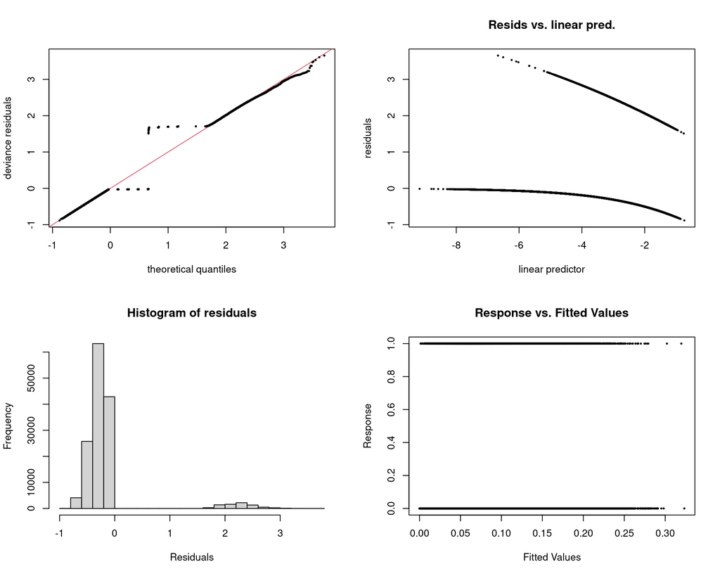

```
##
## Method: REML   Optimizer: outer newton
## full convergence after 6 iterations.
## Gradient range [3.172787e-09,0.0001131974]
## (score 27022.69 & scale 1).
## Hessian positive definite, eigenvalue range [1.114928,3.513423].
## Model rank =  47 / 47
##
## Basis dimension (k) checking results. Low p-value (k-index<1) may
## indicate that k is too low, especially if edf is close to k'.
##
##               k'  edf k-index p-value
## s(hour_num) 8.00 7.52    0.94    0.23
## s(age)      5.00 4.66    0.95    0.39
```

```r
par(mfrow = c(2, 2))
mgcv::gam.check(mod_gam, pch = 19, cex = 0.3)
```

```r
par(mfrow = c(1, 1))
```

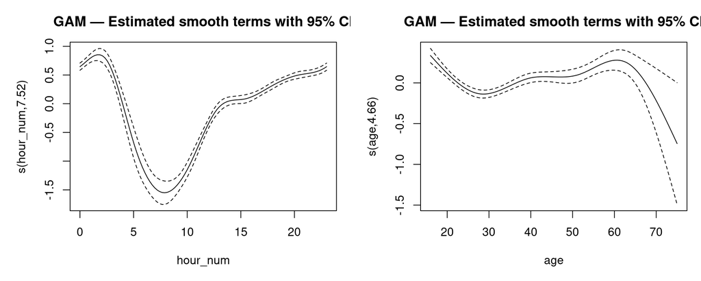

```r
par(mfrow = c(1, 2))
plot(
  mod_gam,
  shade     = TRUE,
  shade.col = "lightblue",
  seWithMean = TRUE,
  scale     = 0,
  pages     = 1,
  main      = "GAM — Estimated smooth terms with 95% CI"
)
```

```r
par(mfrow = c(1, 1))
```

The Q-Q plot assesses normality of deviance residuals — for logistic GAMs, heavy tails or systematic curvature indicate model misspecification. The residuals vs fitted plot should show no trend; a funnel or arch suggests an omitted non-linear term or interaction. The smooth-term plots (second figure) show the estimated partial effect of `hour_num` and `age` on the log-odds of arrest: a flat line within the confidence band would indicate the smooth contributes no signal, while a pronounced curve validates the non-linear specification over a simpler linear term.